# The Sower

by Kameron and Holly York

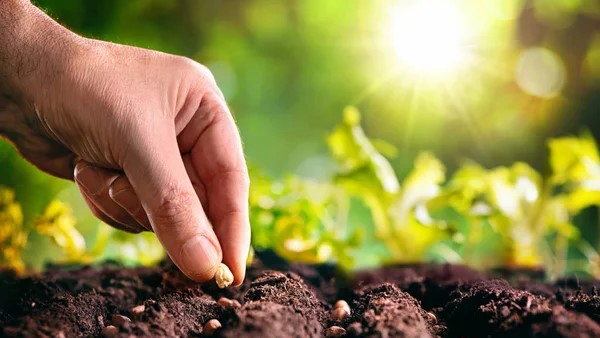

#### Reference:

[Matthew 13:1-9](https://www.churchofjesuschrist.org/study/scriptures/nt/matt/13?lang=eng&id=1-9#p1)  
[Mark 4:3-9](https://www.churchofjesuschrist.org/study/scriptures/nt/mark/4?lang=eng&id=3-9#p3)  
[Luke 8:4-8](https://www.churchofjesuschrist.org/study/scriptures/nt/luke/8?lang=eng&id=4-8#p4)

In 2015 Elder Dallin H. Oaks gave a talk entirely about this parable entitled, “The Parable of the Sower”. In describing the parable he said, “The parable of the sower is one of a small number of parables reported in all three of the synoptic Gospels. It is also one of an even smaller group of parables Jesus explained to His disciples.” We would like to briefly touch on the overall story, along with the similarities and difference between the accounts in each gospel.

#### What is the Parable of the Sower about?

Each gospel tells the same underlying story. A farmer worked in his field sowing seeds into a variety of places. Four significant places are outlined: **The wayside** meaning the side of a road. These seeds had no earth to cover them up and were quickly eaten by birds. **Stony Places** which means the seeds have some soil, but not enough to let their roots grow down deep. Because of this lack of depth they spring out of the soil quickly and are scorched by the sun. **Thorns** that grow up alongside the plants and choke out their life - and external force. **Good soil** which is the antithesis of the other kinds of soil. The seed is buried in the soil where birds can’t reach it, without stones to block the growth of its roots, and there are no thorns to stunt its growth. These are the seeds that bring forth fruit.

#### What are the Differences Between the Accounts?

The accounts of the parable in Matthew and Mark are more or less identical. The only major difference I could find was the order in which they list the amounts of fruit that come from the good seed (Matthew saying 100-60-30 and Mark saying 30-60-100). Luke, on the other hand, has a couple significant differences from the other two. Matthew and Mark note that birds eat up the seeds that fall on the wayside, but Luke first notes that they are “trodden down” before they are eaten. While Matthew and Mark say the second seeds fall, “…stony places…” Luke says they fell on, “…a rock…”. Finally, in telling of the amount of fruit the good seed bears Luke only says it brought forth 100 fold, while the other two accounts mentions some that bring for 60 fold and 30 fold. Overall, however, the underlying story is the same.

#### What do the Symbols in the Parable Represent?

Now, what do each of the symbols in the parable represent. These are the symbols that I can find, broken into the different parts of the parable: **The Sower** represents the Lord. **The Seed** represents the word of God - the Gospel of Jesus Christ. ([Mark 4:14](https://www.churchofjesuschrist.org/study/scriptures/nt/mark/4?lang=eng&id=14#p14))

The Wayside  
**The wayside** represents the world and **the birds** represent satan stealing away the word before it can grow ([Mark 4:15](https://www.churchofjesuschrist.org/study/scriptures/nt/mark/4?lang=eng&id=15#p15)). Luke mentioning the seeds were trodden over invokes an image of a crowd making fun of the word, and “setting it at naught”.

Stony Places  
**The Stones** appear to be under the surface of the soil, so the seed can sprout but cannot grow roots. This could be underlying doubts or bitterness - things only found under the surface. **The Sun** represents persecutions and afflictions - trials ([Mark 4:17](https://www.churchofjesuschrist.org/study/scriptures/nt/mark/4?lang=eng&id=17#p17)). It is interesting that plants *need* the sun in order to survive, but it is when they lack roots that the sun is bad for them. **The Withering** Jesus says is being offended. Luke mentions that these plants wither away because they lacked **moisture** which represents things that feed a testimony. These seeds weren’t in a place to receive that moisture, or they weren’t trying to be.

Among Thorns  
**The Thorns** represent, “…the cares of this world, and the deceitfulness of riches, and the lusts of other things…” ([Mark 4:19](https://www.churchofjesuschrist.org/study/scriptures/nt/mark/4?lang=eng&id=19#p19)). **The Choking** represents allowing these impure things to take over their life.

Good Soil  
**The Good Soil** represents an open and willing heart. **The Fruit** represents good works. The types of people who receive the word and act on it will produce good deeds for their fellow men. It is interesting how often Jesus relates good works/deeds to fruits, like, “by their fruits ye shall know them,” in speaking of good people.  
I enjoyed this section of Elder Dallin H. Oak’s message in speaking of the good soil, “It is up to each of us to set the priorities and to do the things that make our soil good and our harvest plentiful. We must seek to be firmly rooted and converted to the gospel of Jesus Christ.” As we root our lives in the gospel of Jesus Christ we need to make sure there are no birds, stones, or thorns that could threaten the fruitfulness of our soils.  
It is also interesting to me that the Lord describes different amounts being harvested from the seeds in the good soil. Every produces good fruits in their own ways. It should be noted that the trees that bring forth fruit 30 fold are in the same soil as the trees that bring for fruit 100 fold. At times we can be burdened with comparison, to the point of feeling that we simply aren’t doing enough. In these times it would be important to reflect on our soil and remember the goodness of the seed that got us here in the first place.

[output not shown]